# Flight_price_project_final

```python
import pandas as pd
sampled_df=pd.read_csv("Clean_Dataset.csv");
```

The command `sampled_df.head()` displays the first few rows (default: 5 rows) of the DataFrame named `sampled_df`, providing a quick preview of the dataset.

```python
sampled_df.head()
```

|  | Unnamed: 0 | airline | flight | source_city | departure_time | stops | arrival_time | destination_city | class | duration | days_left | price |
| --- | --- | --- | --- | --- | --- | --- | --- | --- | --- | --- | --- | --- |
| 0 | 0 | SpiceJet | SG-8709 | Delhi | Evening | zero | Night | Mumbai | Economy | 2.17 | 1 | 5953 |
| 1 | 1 | SpiceJet | SG-8157 | Delhi | Early_Morning | zero | Morning | Mumbai | Economy | 2.33 | 1 | 5953 |
| 2 | 2 | AirAsia | I5-764 | Delhi | Early_Morning | zero | Early_Morning | Mumbai | Economy | 2.17 | 1 | 5956 |
| 3 | 3 | Vistara | UK-995 | Delhi | Morning | zero | Afternoon | Mumbai | Economy | 2.25 | 1 | 5955 |
| 4 | 4 | Vistara | UK-963 | Delhi | Morning | zero | Morning | Mumbai | Economy | 2.33 | 1 | 5955 |

```python
sampled_df.describe
sampled_df
```

|  | Unnamed: 0 | airline | flight | source_city | departure_time | stops | arrival_time | destination_city | class | duration | days_left | price |
| --- | --- | --- | --- | --- | --- | --- | --- | --- | --- | --- | --- | --- |
| 0 | 0 | SpiceJet | SG-8709 | Delhi | Evening | zero | Night | Mumbai | Economy | 2.17 | 1 | 5953 |
| 1 | 1 | SpiceJet | SG-8157 | Delhi | Early_Morning | zero | Morning | Mumbai | Economy | 2.33 | 1 | 5953 |
| 2 | 2 | AirAsia | I5-764 | Delhi | Early_Morning | zero | Early_Morning | Mumbai | Economy | 2.17 | 1 | 5956 |
| 3 | 3 | Vistara | UK-995 | Delhi | Morning | zero | Afternoon | Mumbai | Economy | 2.25 | 1 | 5955 |
| 4 | 4 | Vistara | UK-963 | Delhi | Morning | zero | Morning | Mumbai | Economy | 2.33 | 1 | 5955 |
| ... | ... | ... | ... | ... | ... | ... | ... | ... | ... | ... | ... | ... |
| 300148 | 300148 | Vistara | UK-822 | Chennai | Morning | one | Evening | Hyderabad | Business | 10.08 | 49 | 69265 |
| 300149 | 300149 | Vistara | UK-826 | Chennai | Afternoon | one | Night | Hyderabad | Business | 10.42 | 49 | 77105 |
| 300150 | 300150 | Vistara | UK-832 | Chennai | Early_Morning | one | Night | Hyderabad | Business | 13.83 | 49 | 79099 |
| 300151 | 300151 | Vistara | UK-828 | Chennai | Early_Morning | one | Evening | Hyderabad | Business | 10.00 | 49 | 81585 |
| 300152 | 300152 | Vistara | UK-822 | Chennai | Morning | one | Evening | Hyderabad | Business | 10.08 | 49 | 81585 |

300153 rows × 12 columns

```python
The above dataset have 300153 rows i want to perform my model on 10,000 data so i will take random sample from the above dataset , for that i will use sample() methord
```

```python
desired_sample_size = 10000

# Randomly sample the dataset
sampled_df = sampled_df.sample(n=desired_sample_size, random_state=42)
```

```python
sampled_df.describe
sampled_df
```

|  | Unnamed: 0 | airline | flight | source_city | departure_time | stops | arrival_time | destination_city | class | duration | days_left | price |
| --- | --- | --- | --- | --- | --- | --- | --- | --- | --- | --- | --- | --- |
| 27131 | 27131 | Air_India | AI-506 | Delhi | Morning | one | Early_Morning | Kolkata | Economy | 19.75 | 40 | 7366 |
| 266857 | 266857 | Vistara | UK-706 | Kolkata | Morning | one | Night | Mumbai | Business | 9.83 | 42 | 64831 |
| 141228 | 141228 | Vistara | UK-772 | Kolkata | Morning | one | Night | Bangalore | Economy | 10.50 | 41 | 6195 |
| 288329 | 288329 | Vistara | UK-824 | Chennai | Night | one | Morning | Delhi | Business | 14.50 | 14 | 60160 |
| 97334 | 97334 | Air_India | AI-501 | Bangalore | Afternoon | one | Night | Mumbai | Economy | 8.25 | 20 | 6578 |
| ... | ... | ... | ... | ... | ... | ... | ... | ... | ... | ... | ... | ... |
| 27874 | 27874 | Air_India | AI-803 | Delhi | Early_Morning | one | Evening | Kolkata | Economy | 11.42 | 44 | 6946 |
| 56233 | 56233 | GO_FIRST | G8-575 | Mumbai | Early_Morning | one | Afternoon | Bangalore | Economy | 10.25 | 21 | 4750 |
| 98649 | 98649 | Vistara | UK-814 | Bangalore | Night | one | Early_Morning | Mumbai | Economy | 10.75 | 27 | 6568 |
| 250921 | 250921 | Vistara | UK-854 | Bangalore | Evening | zero | Night | Mumbai | Business | 1.83 | 28 | 20760 |
| 244645 | 244645 | Air_India | AI-660 | Mumbai | Evening | one | Morning | Chennai | Business | 14.92 | 46 | 49613 |

10000 rows × 12 columns

To checks the missing values in each column of the DataFrame `sampled_df` and count of the null values for each column we will use below methord

```python
sampled_df.isnull().sum()
```

```
Unnamed: 0          0
airline             0
flight              0
source_city         0
departure_time      0
stops               0
arrival_time        0
destination_city    0
class               0
duration            0
days_left           0
price               0
dtype: int64
```

As we can see that our data set have no null or missing values So we move to the next step that is to make the non numerical attributes to the numerical attributes

```python
from sklearn.preprocessing import LabelEncoder
le = LabelEncoder()

# Fit and transform the 'departure_time' column
sampled_df['departure_time_encoded'] = le.fit_transform(sampled_df['departure_time'])

# Display the DataFrame with the new encoded column
print(sampled_df[['departure_time', 'departure_time_encoded']])
```

```
       departure_time  departure_time_encoded
27131         Morning                       4
266857        Morning                       4
141228        Morning                       4
288329          Night                       5
97334       Afternoon                       0
...               ...                     ...
27874   Early_Morning                       1
56233   Early_Morning                       1
98649           Night                       5
250921        Evening                       2
244645        Evening                       2

[10000 rows x 2 columns]
```

1-The 'departure_time' values are encoded into numerical representations, and the results are stored in a new column named 'departure_time_encoded.' 2-This encoding is useful for converting categorical data into a format suitable for machine learning models that require numerical input 3-The transformed DataFrame is displayed, showing both the original 'departure_time' column and the corresponding 'departure_time_encoded' column. 4- similarly we do it for the other attributes

```python
le = LabelEncoder()

# Fit and transform the 'departure_time' column
sampled_df['arrival_time_encoded'] = le.fit_transform(sampled_df['arrival_time'])

# Display the DataFrame with the new encoded column
print(sampled_df[['arrival_time', 'arrival_time_encoded']])
```

```
         arrival_time  arrival_time_encoded
27131   Early_Morning                     1
266857          Night                     5
141228          Night                     5
288329        Morning                     4
97334           Night                     5
...               ...                   ...
27874         Evening                     2
56233       Afternoon                     0
98649   Early_Morning                     1
250921          Night                     5
244645        Morning                     4

[10000 rows x 2 columns]
```

```python
le = LabelEncoder()

# Fit and transform the 'departure_time' column
sampled_df['class_type_encoded'] = le.fit_transform(sampled_df['class'])

# Display the mapping between original values and encoded values
print("Mapping of class type values to numerical labels:")
for original, encoded in zip(le.classes_, le.transform(le.classes_)):
    print(f"{original}: {encoded}")

# Display the DataFrame with the new encoded column
print(sampled_df[['class', 'class_type_encoded']])
```

```
Mapping of class type values to numerical labels:
Business: 0
Economy: 1
           class  class_type_encoded
27131    Economy                   1
266857  Business                   0
141228   Economy                   1
288329  Business                   0
97334    Economy                   1
...          ...                 ...
27874    Economy                   1
56233    Economy                   1
98649    Economy                   1
250921  Business                   0
244645  Business                   0

[10000 rows x 2 columns]
```

```python
from sklearn.preprocessing import LabelEncoder
le = LabelEncoder()

# Fit and transform the 'departure_time' column
sampled_df['destination_city_encoded'] = le.fit_transform(sampled_df['destination_city'])
# Display the mapping between original values and encoded values
print("Mapping of destination_city values to numerical labels:")
for original, encoded in zip(le.classes_, le.transform(le.classes_)):
    print(f"{original}: {encoded}")

# Display the DataFrame with the new encoded column
print(sampled_df[['destination_city', 'destination_city_encoded']])
```

```
Mapping of destination_city values to numerical labels:
Bangalore: 0
Chennai: 1
Delhi: 2
Hyderabad: 3
Kolkata: 4
Mumbai: 5
       destination_city  destination_city_encoded
27131           Kolkata                         4
266857           Mumbai                         5
141228        Bangalore                         0
288329            Delhi                         2
97334            Mumbai                         5
...                 ...                       ...
27874           Kolkata                         4
56233         Bangalore                         0
98649            Mumbai                         5
250921           Mumbai                         5
244645          Chennai                         1

[10000 rows x 2 columns]
```

```python
from sklearn.preprocessing import LabelEncoder
le = LabelEncoder()

# Fit and transform the 'departure_time' column
sampled_df['source_city_encoded'] = le.fit_transform(sampled_df['source_city'])
# Display the mapping between original values and encoded values
print("Mapping of source_city values to numerical labels:")
for original, encoded in zip(le.classes_, le.transform(le.classes_)):
    print(f"{original}: {encoded}")

# Display the DataFrame with the new encoded column
print(sampled_df[['source_city', 'source_city_encoded']])
```

```
Mapping of source_city values to numerical labels:
Bangalore: 0
Chennai: 1
Delhi: 2
Hyderabad: 3
Kolkata: 4
Mumbai: 5
       source_city  source_city_encoded
27131        Delhi                    2
266857     Kolkata                    4
141228     Kolkata                    4
288329     Chennai                    1
97334    Bangalore                    0
...            ...                  ...
27874        Delhi                    2
56233       Mumbai                    5
98649    Bangalore                    0
250921   Bangalore                    0
244645      Mumbai                    5

[10000 rows x 2 columns]
```

```python
from sklearn.preprocessing import LabelEncoder
le = LabelEncoder()

# Fit and transform the 'departure_time' column
sampled_df['airline_encoded'] = le.fit_transform(sampled_df['airline'])
# Display the mapping between original values and encoded values
print("Mapping of airline values to numerical labels:")
for original, encoded in zip(le.classes_, le.transform(le.classes_)):
    print(f"{original}: {encoded}")
# Display the DataFrame with the new encoded column
print(sampled_df[['airline', 'airline_encoded']])
```

```
Mapping of airline values to numerical labels:
AirAsia: 0
Air_India: 1
GO_FIRST: 2
Indigo: 3
SpiceJet: 4
Vistara: 5
          airline  airline_encoded
27131   Air_India                1
266857    Vistara                5
141228    Vistara                5
288329    Vistara                5
97334   Air_India                1
...           ...              ...
27874   Air_India                1
56233    GO_FIRST                2
98649     Vistara                5
250921    Vistara                5
244645  Air_India                1

[10000 rows x 2 columns]
```

```python
from sklearn.preprocessing import LabelEncoder
le = LabelEncoder()

# Fit and transform the 'departure_time' column
sampled_df['flight_encoded'] = le.fit_transform(sampled_df['flight'])
#print("Mapping of flight name to numerical labels:")
#for original, encoded in zip(le.classes_, le.transform(le.classes_)):
 #   print(f"{original}: {encoded}")
# Display the DataFrame with the new encoded column
print(sampled_df[['flight', 'flight_encoded']])
```

```
        flight  flight_encoded
27131   AI-506             486
266857  UK-706            1019
141228  UK-772            1028
288329  UK-824            1053
97334   AI-501             481
...        ...             ...
27874   AI-803             581
56233   G8-575             755
98649   UK-814            1043
250921  UK-854            1077
244645  AI-660             539

[10000 rows x 2 columns]
```

```python
from sklearn.preprocessing import LabelEncoder
le = LabelEncoder()

# Fit and transform the 'departure_time' column
sampled_df['stops_encoded'] = le.fit_transform(sampled_df['stops'])
# Display the mapping between original values and encoded values
print("Mapping of stops to numerical labels:")
for original, encoded in zip(le.classes_, le.transform(le.classes_)):
    print(f"{original}: {encoded}")
# Display the DataFrame with the new encoded column
print(sampled_df[['stops', 'stops_encoded']])
```

```
Mapping of stops to numerical labels:
one: 0
two_or_more: 1
zero: 2
       stops  stops_encoded
27131    one              0
266857   one              0
141228   one              0
288329   one              0
97334    one              0
...      ...            ...
27874    one              0
56233    one              0
98649    one              0
250921  zero              2
244645   one              0

[10000 rows x 2 columns]
```

After converting categorical data into a format suitable for machine learning models that require numerical input we will see the modified dataset

```python
sampled_df
```

|  | Unnamed: 0 | airline | flight | source_city | departure_time | stops | arrival_time | destination_city | class | duration | days_left | price | stops_encoded | flight_encoded | airline_encoded | source_city_encoded | destination_city_encoded | class_type_encoded | arrival_time_encoded | departure_time_encoded |
| --- | --- | --- | --- | --- | --- | --- | --- | --- | --- | --- | --- | --- | --- | --- | --- | --- | --- | --- | --- | --- |
| 27131 | 27131 | Air_India | AI-506 | Delhi | Morning | one | Early_Morning | Kolkata | Economy | 19.75 | 40 | 7366 | 0 | 486 | 1 | 2 | 4 | 1 | 1 | 4 |
| 266857 | 266857 | Vistara | UK-706 | Kolkata | Morning | one | Night | Mumbai | Business | 9.83 | 42 | 64831 | 0 | 1019 | 5 | 4 | 5 | 0 | 5 | 4 |
| 141228 | 141228 | Vistara | UK-772 | Kolkata | Morning | one | Night | Bangalore | Economy | 10.50 | 41 | 6195 | 0 | 1028 | 5 | 4 | 0 | 1 | 5 | 4 |
| 288329 | 288329 | Vistara | UK-824 | Chennai | Night | one | Morning | Delhi | Business | 14.50 | 14 | 60160 | 0 | 1053 | 5 | 1 | 2 | 0 | 4 | 5 |
| 97334 | 97334 | Air_India | AI-501 | Bangalore | Afternoon | one | Night | Mumbai | Economy | 8.25 | 20 | 6578 | 0 | 481 | 1 | 0 | 5 | 1 | 5 | 0 |
| ... | ... | ... | ... | ... | ... | ... | ... | ... | ... | ... | ... | ... | ... | ... | ... | ... | ... | ... | ... | ... |
| 27874 | 27874 | Air_India | AI-803 | Delhi | Early_Morning | one | Evening | Kolkata | Economy | 11.42 | 44 | 6946 | 0 | 581 | 1 | 2 | 4 | 1 | 2 | 1 |
| 56233 | 56233 | GO_FIRST | G8-575 | Mumbai | Early_Morning | one | Afternoon | Bangalore | Economy | 10.25 | 21 | 4750 | 0 | 755 | 2 | 5 | 0 | 1 | 0 | 1 |
| 98649 | 98649 | Vistara | UK-814 | Bangalore | Night | one | Early_Morning | Mumbai | Economy | 10.75 | 27 | 6568 | 0 | 1043 | 5 | 0 | 5 | 1 | 1 | 5 |
| 250921 | 250921 | Vistara | UK-854 | Bangalore | Evening | zero | Night | Mumbai | Business | 1.83 | 28 | 20760 | 2 | 1077 | 5 | 0 | 5 | 0 | 5 | 2 |
| 244645 | 244645 | Air_India | AI-660 | Mumbai | Evening | one | Morning | Chennai | Business | 14.92 | 46 | 49613 | 0 | 539 | 1 | 5 | 1 | 0 | 4 | 2 |

10000 rows × 20 columns

Now in the above dataset we can see that the categorical data are converted into new atributes which have the numerical data

The code calculates the pairwise correlation between numerical columns in the DataFrame we will use corr() methord

```python
sampled_df.corr()
```

|  | Unnamed: 0 | duration | days_left | price | stops_encoded | flight_encoded | airline_encoded | source_city_encoded | destination_city_encoded | class_type_encoded | arrival_time_encoded | departure_time_encoded |
| --- | --- | --- | --- | --- | --- | --- | --- | --- | --- | --- | --- | --- |
| Unnamed: 0 | 1.000000 | 0.176577 | 0.014602 | 0.758155 | -0.123459 | 0.203911 | 0.177108 | -0.083641 | 0.020471 | -0.800988 | 0.013125 | 0.079345 |
| duration | 0.176577 | 1.000000 | -0.039263 | 0.211685 | -0.463801 | 0.185596 | -0.006552 | -0.009083 | 0.021928 | -0.153988 | -0.000597 | 0.090356 |
| days_left | 0.014602 | -0.039263 | 1.000000 | -0.103214 | -0.006167 | 0.006088 | -0.009711 | -0.000722 | -0.032370 | 0.024039 | -0.010206 | -0.004261 |
| price | 0.758155 | 0.211685 | -0.103214 | 1.000000 | -0.196331 | 0.302738 | 0.251281 | 0.007341 | 0.016653 | -0.938068 | 0.024711 | 0.049364 |
| stops_encoded | -0.123459 | -0.463801 | -0.006167 | -0.196331 | 1.000000 | -0.089723 | -0.018306 | 0.018104 | -0.028949 | 0.096107 | 0.019241 | 0.002270 |
| flight_encoded | 0.203911 | 0.185596 | 0.006088 | 0.302738 | -0.089723 | 1.000000 | 0.651090 | -0.020425 | -0.042978 | -0.257557 | 0.065401 | 0.076536 |
| airline_encoded | 0.177108 | -0.006552 | -0.009711 | 0.251281 | -0.018306 | 0.651090 | 1.000000 | -0.032779 | -0.038101 | -0.189846 | 0.047265 | 0.043729 |
| source_city_encoded | -0.083641 | -0.009083 | -0.000722 | 0.007341 | 0.018104 | -0.020425 | -0.032779 | 1.000000 | -0.223457 | -0.005676 | 0.038177 | 0.004266 |
| destination_city_encoded | 0.020471 | 0.021928 | -0.032370 | 0.016653 | -0.028949 | -0.042978 | -0.038101 | -0.223457 | 1.000000 | -0.007136 | -0.020099 | -0.014108 |
| class_type_encoded | -0.800988 | -0.153988 | 0.024039 | -0.938068 | 0.096107 | -0.257557 | -0.189846 | -0.005676 | -0.007136 | 1.000000 | -0.009177 | -0.046382 |
| arrival_time_encoded | 0.013125 | -0.000597 | -0.010206 | 0.024711 | 0.019241 | 0.065401 | 0.047265 | 0.038177 | -0.020099 | -0.009177 | 1.000000 | -0.036925 |
| departure_time_encoded | 0.079345 | 0.090356 | -0.004261 | 0.049364 | 0.002270 | 0.076536 | 0.043729 | 0.004266 | -0.014108 | -0.046382 | -0.036925 | 1.000000 |

This visualization helps identify patterns of correlation among different attributes in the dataset, providing insights into potential relationships between variables.

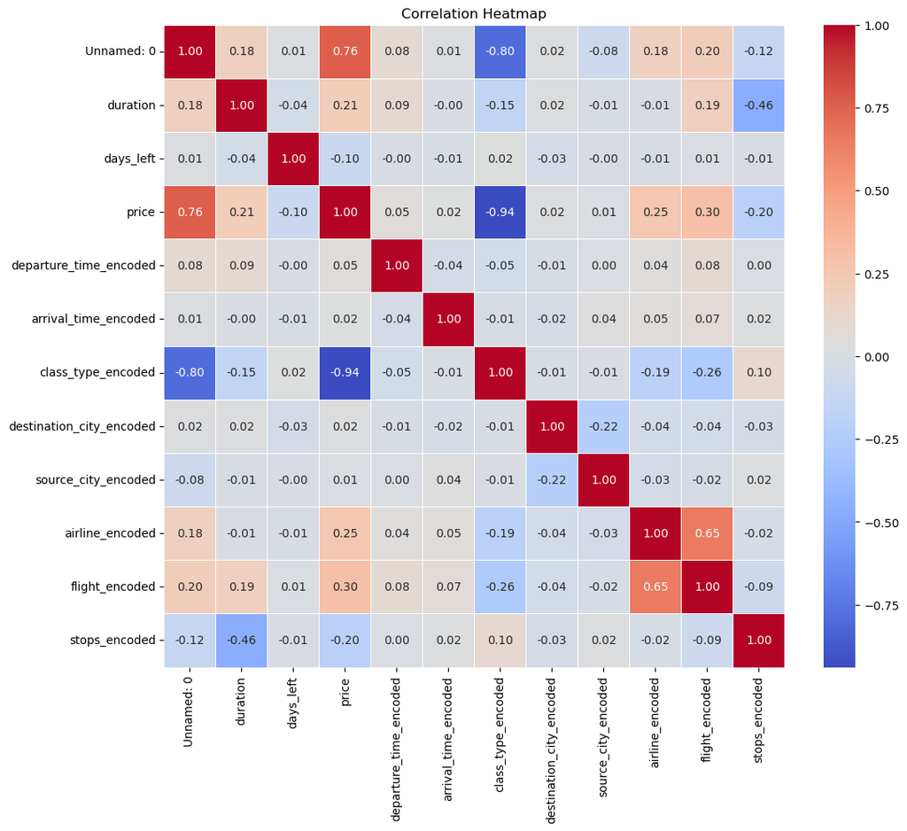

```python
import seaborn as sns
import matplotlib.pyplot as plt

correlation_matrix = sampled_df.corr()
plt.figure(figsize=(12, 10))
sns.heatmap(correlation_matrix, annot=True, cmap='coolwarm', fmt=".2f", linewidths=0.5)
plt.title('Correlation Heatmap')
plt.show()
```

[figure not shown]

```python
sns.pairplot(sampled_df[['duration', 'days_left', 'class_type_encoded', 'stops_encoded', 'airline_encoded', 'flight_encoded','source_city_encoded','destination_city_encoded','arrival_time_encoded','departure_time_encoded', 'price']])
plt.show()
```

Each subplot in the pairplot displays scatter plots for pairs of attributes along with histograms on the diagonal. This visualization allows for a quick examination of relationships and distributions between the selected variables, providing insights into potential patterns or trends.

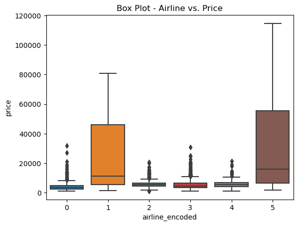

```python
# Box plot for Airline
sns.boxplot(x='airline_encoded', y='price', data=sampled_df)
plt.title('Box Plot - Airline vs. Price')
plt.show()
```

The box plot helps in understanding the central tendency, spread, and potential outliers in the price distribution for each airline. The title of the plot is set as 'Box Plot - Airline vs. Price.'

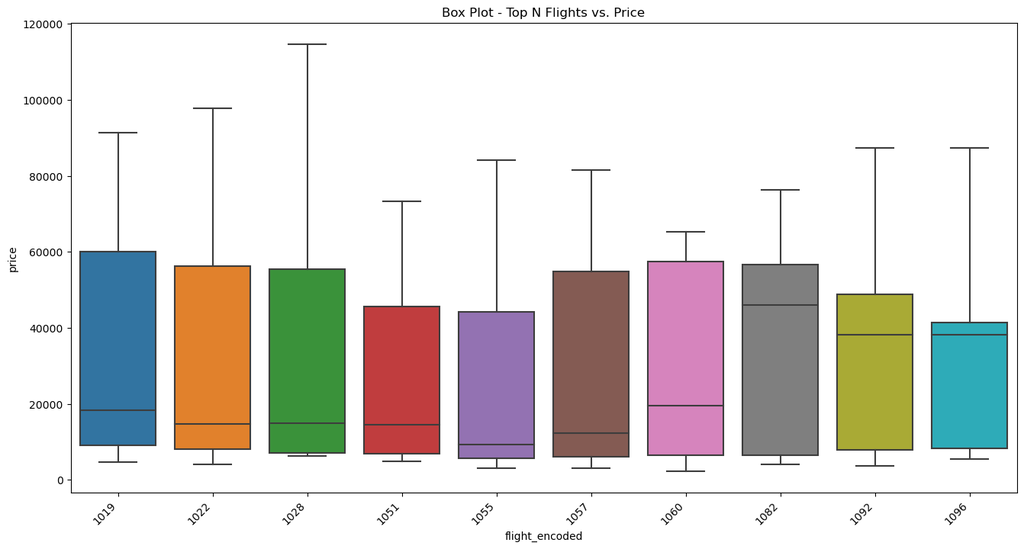

```python
# Choose the top N flights based on frequency or median prices
top_n_flights = sampled_df['flight_encoded'].value_counts().nlargest(10).index

# Filter the dataframe for the top N flights
top_flights_df = sampled_df[sampled_df['flight_encoded'].isin(top_n_flights)]

# Increase figure size
plt.figure(figsize=(16, 8))

# Box plot for top N flights
sns.boxplot(x='flight_encoded', y='price', data=top_flights_df)
plt.title('Box Plot - Top N Flights vs. Price')
plt.xticks(rotation=45, ha='right')
plt.show()
```

This plot helps in comparing the price distribution for each of the selected flights, providing insights into potential variations in prices among the most frequent or popular flights. The title of the plot is set as 'Box Plot - Top N Flights vs. Price.'

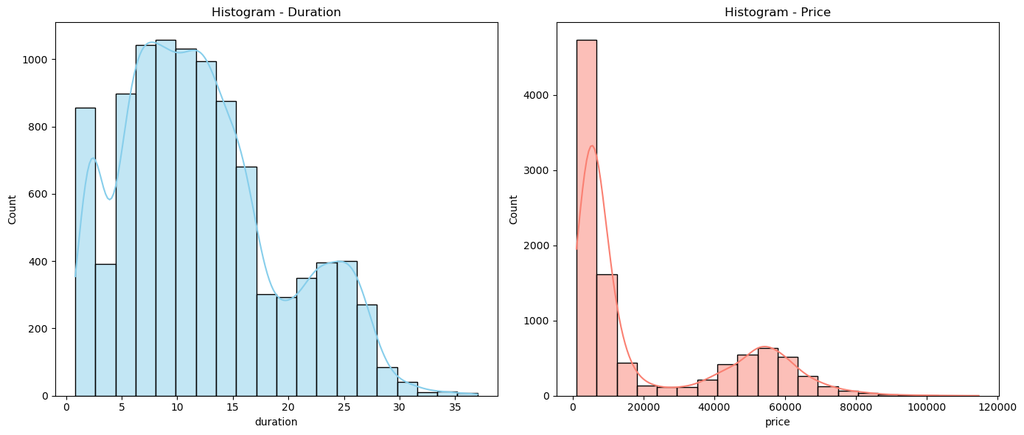

```python
import seaborn as sns
import matplotlib.pyplot as plt

# Increase figure size
plt.figure(figsize=(14, 6))

# Subplot 1: Histogram and KDE for 'duration'
plt.subplot(1, 2, 1)
sns.histplot(sampled_df['duration'], kde=True, bins=20, color='skyblue')
plt.title('Histogram - Duration')

# Subplot 2: Histogram and KDE for 'price'
plt.subplot(1, 2, 2)
sns.histplot(sampled_df['price'], kde=True, bins=20, color='salmon')
plt.title('Histogram - Price')

plt.tight_layout()
plt.show()
```

This visualization allows for an examination of the distribution and central tendency of both 'duration' and 'price' in the DataFrame sampled_df. The figure size is increased, and the subplots are arranged for better visibility.

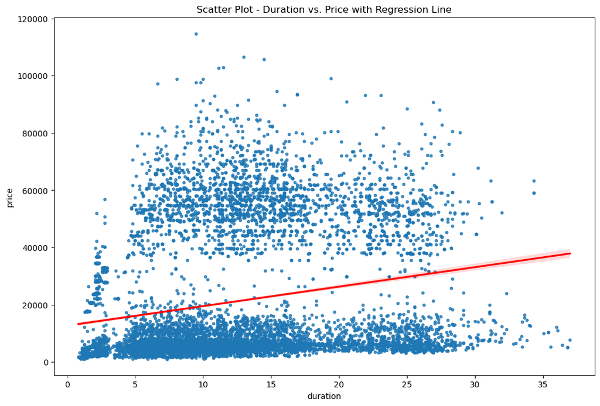

```python
import seaborn as sns
import matplotlib.pyplot as plt

# Increase figure size
plt.figure(figsize=(12, 8))

# Scatter plot with regression line
sns.regplot(x='duration', y='price', data=sampled_df, scatter_kws={'s':10}, line_kws={'color':'red'})
plt.title('Scatter Plot - Duration vs. Price with Regression Line')
plt.show()
```

This plot allows for an examination of the correlation between flight duration and price, with the red regression line indicating the estimated linear relationship between the two variables. The figure size is increased, and the title is set as 'Scatter Plot - Duration vs. Price with Regression Line.'

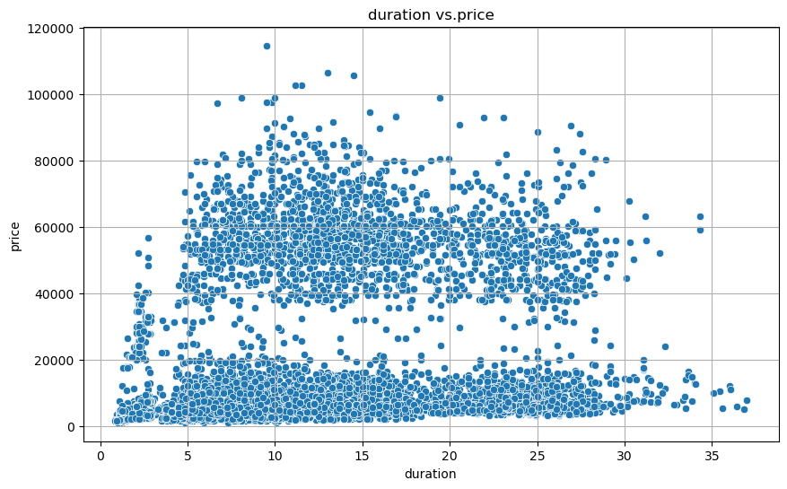

```python
import seaborn as sns
import matplotlib.pyplot as plt

plt.figure(figsize=(10, 6))
sns.scatterplot(x='duration', y='price', data=sampled_df)
plt.title('duration vs.price')
plt.xlabel('duration')
plt.ylabel('price')
plt.grid(True)
plt.show()
```

The code creates a scatter plot using seaborn and matplotlib, illustrating the relationship between 'duration' and 'price' in the DataFrame sampled_df. Each point on the plot represents a data instance, showing the distribution of flight durations and corresponding prices.

LINEAR REGRESSION MODEL

```python
from sklearn.model_selection import train_test_split
from sklearn.linear_model import LinearRegression
from sklearn.metrics import mean_squared_error, r2_score
X = sampled_df[['duration', 'days_left','departure_time_encoded','class_type_encoded','arrival_time_encoded','destination_city_encoded','source_city_encoded','airline_encoded','flight_encoded','stops_encoded']]
y = sampled_df['price']
# Split the data into a training set and a testing set
X_train, X_test, y_train, y_test = train_test_split(X, y, test_size=0.2, random_state=42)

# Create a linear regression model
model = LinearRegression()

# Train the model
model.fit(X_train, y_train)

# Make predictions on the test set
y_pred = model.predict(X_test)

# Evaluate the model
mse_linear = mean_squared_error(y_test, y_pred)
r2_linear = r2_score(y_test, y_pred)

print(f"Mean Squared Error (MSE): {mse_linear}")
print(f"R-squared (R2): {r2_linear}")
```

```
Mean Squared Error (MSE): 50434463.47269087
R-squared (R2): 0.9061678407898197
```

The Mean Squared Error (MSE) value of approximately 50,434,463.47 indicates the average squared difference between the predicted flight prices and the actual prices in the test set. Lower MSE values are desirable, suggesting that the model's predictions are closer to the actual values.

The R-squared (R2) value of approximately 0.906 indicates the proportion of variance in the target variable (flight prices) that can be explained by the model. An R2 score closer to 1.0 suggests that the model explains a large portion of the variance in the target variable, indicating a good fit.

RANDOM_FOREST_REGRESSOR MODEL

```python
from sklearn.model_selection import train_test_split
from sklearn.ensemble import RandomForestRegressor
from sklearn.metrics import mean_squared_error, r2_score

# Assuming 'sampled_df' is your DataFrame

# Selecting features and target variable
X = sampled_df[['duration', 'days_left', 'departure_time_encoded', 'class_type_encoded', 'arrival_time_encoded',
                'destination_city_encoded', 'source_city_encoded', 'airline_encoded', 'flight_encoded', 'stops_encoded']]
y = sampled_df['price']

# Split the data into a training set and a testing set
X_train, X_test, y_train, y_test = train_test_split(X, y, test_size=0.2, random_state=42)

# List of regression models
model_rf =  RandomForestRegressor()
# Train the model
model_rf.fit(X_train, y_train)

# Make predictions on the test set
y_pred = model_rf.predict(X_test)

mse = mean_squared_error(y_test, y_pred)
r2 = r2_score(y_test, y_pred)

print(f"Mean Squared Error (MSE) for {name}: {mse}")
print(f"R-squared (R2) for {name}: {r2}\n")
```

[output not shown]

The Mean Squared Error (MSE) of approximately 15,028,529.11 indicates the average squared difference between the predicted flight prices and the actual prices in the test set. A lower MSE is desirable, and the value you obtained suggests that the Random Forest Regression model provides accurate predictions with relatively small errors.

The R-squared (R2) value of approximately 0.972 indicates that the Random Forest model explains about 97.2% of the variance in the target variable (flight prices). This high R2 score suggests that the model fits the data very well, capturing a significant portion of the variability in flight prices based on the selected features. Overall, these results indicate that the Random Forest Regression model is performing well on the given dataset.

Now from the above two model we will find that which model is best fitting

```python
model_names = ['Linear Regression', 'Random_Forest_Regressor']
import numpy as np
# MSE scores
mse_scores = [mse_linear, mse]

# R2 scores
r2_scores = [r2_linear, r2]
best_model_mse = model_names[np.argmin(mse_scores)]
print(f'Best model based on Mean Squared Error (MSE): {best_model_mse}')

best_model_r2 = model_names[np.argmax(r2_scores)]
print(f'Best model based on R-squared (R2): {best_model_r2}')
```

```
Best model based on Mean Squared Error (MSE): Random_Forest_Regressor
Best model based on R-squared (R2): Random_Forest_Regressor
```

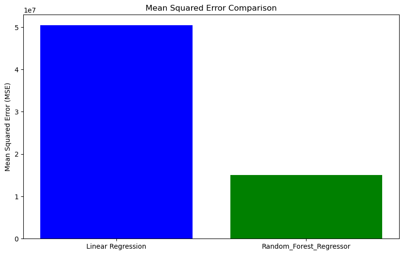

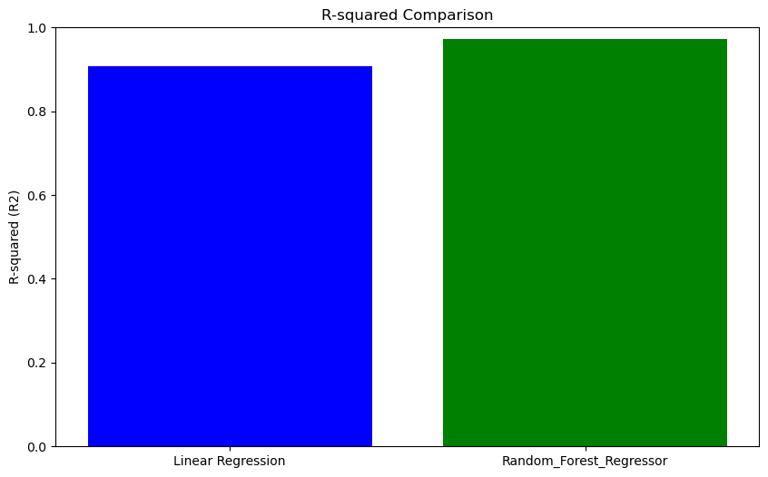

```python
# Bar chart for MSE
plt.figure(figsize=(10, 6))
plt.bar(model_names, mse_scores, color=['blue', 'green'])
plt.title('Mean Squared Error Comparison')
plt.ylabel('Mean Squared Error (MSE)')
plt.show()
# Bar chart for R2
plt.figure(figsize=(10, 6))
plt.bar(model_names, r2_scores, color=['blue', 'green'])
plt.title('R-squared Comparison')
plt.ylabel('R-squared (R2)')
plt.ylim(0, 1)  # R2 score is between 0 and 1
plt.show()
```

From the above comparision we see that Random_Forest_Regressor is performimg very well

So now using the RANDOM_FOREST_REGESSOR model we will predict the Flight Price

So we will take value from user and by the help of the RANDOM_FOREST_REGESSOR model we will predict the flight price in the future

```python
from sklearn.ensemble import RandomForestRegressor
import pandas as pd
import numpy as np

#  user  input
duration = float(input("Enter the duration (in hours): "))
days_left = int(input("Enter the number of days left for the flight: "))
departure_time_encoded=int(input("Enter the departure time  for the flight:afternoon=0Afternoon: 0,Early_Morning: 1,Evening: 2,Late_Night: 3,Morning: 4,Night: 5  "))
class_type_encoded = int(input("Enter the Class type for the flight: 1is for Economy and 0 is for Buisness "))
arrival_time_encoded=int(input("Enter the arrival time for the flight: fternoon=0Afternoon: 0,Early_Morning: 1,Evening: 2,Late_Night: 3,Morning: 4,Night: 5 "))
destination_city_encoded=int(input("Enter the Destination city for the flight: Bangalore: 0-Chennai: 1-Delhi: 2-Hyderabad: 3-Kolkata: 4-Mumbai: 5"))
source_city_encoded=int(input("Enter the SOURCE city for the flight: Bangalore: 0-Chennai: 1-Delhi: 2-Hyderabad: 3-Kolkata: 4-Mumbai: 5"))
airline_encoded=int(input("Enter the AIRLINE NAME for the flight: Bangalore: AirAsia: 0 ,Air_India: 1,GO_FIRST: 2,Indigo: 3,SpiceJet: 4,Vistara: 5"))
flight_encoded= int(input("Enter the name OF THE FLIGHT (THE FLIGHT NAME ARE IN BETWEEN 1-1087): "))
stops_encoded = int(input("Enter the Class type for the flight: choose 0:for 1 , choose 1: for two_or_more , choose 2: for zero"))

# Create a user input dictionary with the values provided by the user
user_input = {
    'duration': duration,
    'days_left': days_left,
    'departure_time_encoded': departure_time_encoded,
    'class_type_encoded': class_type_encoded,
    'arrival_time_encoded': arrival_time_encoded,
    'destination_city_encoded': destination_city_encoded,
    'source_city_encoded': source_city_encoded,
    'airline_encoded': airline_encoded,
    'flight_encoded': flight_encoded,
    'stops_encoded': stops_encoded
}

# Create a DataFrame from the user input
user_df = pd.DataFrame(user_input, index=[0])

# Make sure the column order is the same as during training
user_df = user_df[['duration', 'days_left', 'departure_time_encoded', 'class_type_encoded', 'arrival_time_encoded',
                   'destination_city_encoded', 'source_city_encoded', 'airline_encoded', 'flight_encoded', 'stops_encoded']]

# Perform feature scaling on the user input data using the same scaler used for training
user_df_scaled = scaler.transform(user_df)

# Make price predictions using the RandomForestRegressor model
predicted_prices_rf = model_rf.predict(user_df_scaled)
print(f"Predicted Price using RandomForestRegressor: {predicted_prices_rf[0]}")
```

[output not shown]

```python
now we will use some Classification models to find the best classification model
```

```python
KNN CLASSIFICATION MODEL
```

STEP-1 : Convert 'price' into Categorical Labels:

The 'price' column is converted into categorical labels ('low', 'medium', 'high') based on predefined bins. This categorization is done using the pd.cut function. STEP-2

The LabelEncoder is used to encode categorical labels into numerical values.

STEP-3

The fit_transform method is a combination of two steps: fitting the encoder to the unique values in y_classification and then transforming the original labels into corresponding numerical values.

(test_size=0.2 ) this mean we will train our model with the 80% of data and test the model on the 20% of data

```python
from sklearn.model_selection import train_test_split
from sklearn.neighbors import KNeighborsClassifier
from sklearn.metrics import accuracy_score, precision_score, f1_score, recall_score
from sklearn.preprocessing import LabelEncoder

# Assuming 'sampled_df' is your DataFrame

# Convert the 'price' column into categorical labels (you can customize this based on your specific needs)
price_labels = ['low', 'medium', 'high']
sampled_df['price_category'] = pd.cut(sampled_df['price'], bins=[-float('inf'), 10000, 30000, float('inf')], labels=price_labels)

# Features and target variable for classification
X_classification = sampled_df[['duration', 'days_left', 'departure_time_encoded', 'class_type_encoded', 'arrival_time_encoded',
                                'destination_city_encoded', 'source_city_encoded', 'airline_encoded',
                                'flight_encoded', 'stops_encoded']]
y_classification = sampled_df['price_category']

# Encode categorical labels to numerical values
le = LabelEncoder()
y_classification_encoded = le.fit_transform(y_classification)

# Split the data into a training set and a testing set for classification
X_train_classification, X_test_classification, y_train_classification, y_test_classification = train_test_split(
    X_classification, y_classification_encoded, test_size=0.2, random_state=42
)

# Create a K-Nearest Neighbors (KNN) model
knn_classifier = KNeighborsClassifier(n_neighbors=5)

# Train the KNN model on the training data
knn_classifier.fit(X_train_classification, y_train_classification)

# Make predictions on the testing data
y_pred_classification = knn_classifier.predict(X_test_classification)

# Calculate and print evaluation metrics
accuracy_k = accuracy_score(y_test_classification, y_pred_classification)
precision_k = precision_score(y_test_classification, y_pred_classification, average='weighted')
f1_k = f1_score(y_test_classification, y_pred_classification, average='weighted')
recall_k = recall_score(y_test_classification, y_pred_classification, average='weighted')

print(f'Accuracy: {accuracy_k}')
print(f'Precision: {precision_k}')
print(f'F1 Score: {f1_k}')
print(f'Recall: {recall_k}')
```

```
Accuracy: 0.6525
Precision: 0.6475534831768316
F1 Score: 0.645246726227443
Recall: 0.6525
```

Accuracy (0.6525):

Accuracy represents the proportion of correctly classified instances out of the total instances in the test set. In this case, the model achieved an accuracy of approximately 65.25%, indicating that about 65.25% of the predictions were correct.

Precision (0.6476):

Precision is the ratio of true positive predictions to the total predicted positives (including both true positives and false positives). In this context, precision is approximately 64.76%, meaning that when the model predicts a certain price category, it is correct about 64.76% of the time.

F1 Score (0.6452):

The F1 score is the harmonic mean of precision and recall. It provides a balance between precision and recall. A higher F1 score indicates a better balance between precision and recall. In this case, the F1 score is approximately 64.52%.

Recall (0.6525):

Recall (or sensitivity) is the ratio of true positive predictions to the total actual positives (including both true positives and false negatives). In this context, recall is approximately 65.25%, indicating that the model correctly identified about 65.25% of the instances belonging to the positive class.

```python
Decision_Tree_Classifier Model
```

Similarly like the KNN model we will perform Dcision Tree model and find the accuracy_score, precision_score, f1_score, recall_score

```python
from sklearn.tree import DecisionTreeClassifier
from sklearn.metrics import accuracy_score, precision_score, f1_score, recall_score
from sklearn.preprocessing import LabelEncoder
from sklearn.model_selection import train_test_split

# Assuming 'sampled_df' is your DataFrame

# Convert the 'price' column into categorical labels (you can customize this based on your specific needs)
price_labels = ['low', 'medium', 'high']
sampled_df['price_category'] = pd.cut(sampled_df['price'], bins=[-float('inf'), 10000, 30000, float('inf')], labels=price_labels)

# Features and target variable for classification
X_classification = sampled_df[['duration', 'days_left', 'departure_time_encoded', 'class_type_encoded', 'arrival_time_encoded',
                                'destination_city_encoded', 'source_city_encoded', 'airline_encoded',
                                'flight_encoded', 'stops_encoded']]
y_classification = sampled_df['price_category']

# Encode categorical labels to numerical values
le = LabelEncoder()
y_classification_encoded = le.fit_transform(y_classification)

# Split the data into a training set and a testing set for classification
X_train_classification, X_test_classification, y_train_classification, y_test_classification = train_test_split(
    X_classification, y_classification_encoded, test_size=0.2, random_state=42
)

# Decision Tree Classifier
decision_tree_classifier = DecisionTreeClassifier(random_state=42)
decision_tree_classifier.fit(X_train_classification, y_train_classification)
y_pred_decision_tree = decision_tree_classifier.predict(X_test_classification)

# Evaluate Decision Tree Classifier
accuracy_decision_tree = accuracy_score(y_test_classification, y_pred_decision_tree)
precision_decision_tree = precision_score(y_test_classification, y_pred_decision_tree, average='weighted')
f1_decision_tree = f1_score(y_test_classification, y_pred_decision_tree, average='weighted')
recall_decision_tree = recall_score(y_test_classification, y_pred_decision_tree, average='weighted')

print("Decision Tree Classifier:")
print(f'Accuracy: {accuracy_decision_tree}')
print(f'Precision: {precision_decision_tree}')
print(f'F1 Score: {f1_decision_tree}')
print(f'Recall: {recall_decision_tree}')
```

```
Decision Tree Classifier:
Accuracy: 0.931
Precision: 0.9304476654770234
F1 Score: 0.9307127877860938
Recall: 0.931
```

RANDOM_FOREST_CLASSIFIER MODEL

Similarly like the KNN model we will perform RandomForestClassifier model and find the accuracy_score, precision_score, f1_score, recall_score

```python
from sklearn.ensemble import RandomForestClassifier
from sklearn.metrics import accuracy_score, precision_score, f1_score, recall_score
from sklearn.preprocessing import LabelEncoder
from sklearn.model_selection import train_test_split

# Assuming 'sampled_df' is your DataFrame

# Convert the 'price' column into categorical labels (you can customize this based on your specific needs)
price_labels = ['low', 'medium', 'high']
sampled_df['price_category'] = pd.cut(sampled_df['price'], bins=[-float('inf'), 10000, 30000, float('inf')], labels=price_labels)

# Features and target variable for classification
X_classification = sampled_df[['duration', 'days_left', 'departure_time_encoded', 'class_type_encoded', 'arrival_time_encoded',
                                'destination_city_encoded', 'source_city_encoded', 'airline_encoded',
                                'flight_encoded', 'stops_encoded']]
y_classification = sampled_df['price_category']

# Encode categorical labels to numerical values
le = LabelEncoder()
y_classification_encoded = le.fit_transform(y_classification)

# Split the data into a training set and a testing set for classification
X_train_classification, X_test_classification, y_train_classification, y_test_classification = train_test_split(
    X_classification, y_classification_encoded, test_size=0.2, random_state=42
)

# Random Forest Classifier
random_forest_classifier = RandomForestClassifier(random_state=42)
random_forest_classifier.fit(X_train_classification, y_train_classification)
y_pred_random_forest = random_forest_classifier.predict(X_test_classification)

# Evaluate Random Forest Classifier
accuracy_random_forest = accuracy_score(y_test_classification, y_pred_random_forest)
precision_random_forest = precision_score(y_test_classification, y_pred_random_forest, average='weighted')
f1_random_forest = f1_score(y_test_classification, y_pred_random_forest, average='weighted')
recall_random_forest = recall_score(y_test_classification, y_pred_random_forest, average='weighted')

print("\nRandom Forest Classifier:")
print(f'Accuracy: {accuracy_random_forest}')
print(f'Precision: {precision_random_forest}')
print(f'F1 Score: {f1_random_forest}')
print(f'Recall: {recall_random_forest}')
```

```
Random Forest Classifier:
Accuracy: 0.955
Precision: 0.9537555577119785
F1 Score: 0.9541281485750698
Recall: 0.955
```

Now we will compare the above three model and see which model is performing well

```python
models = [ 'KNN', 'Decision Tree','Random Forest']
acc_scores = [accuracy_k, accuracy_decision_tree,accuracy_random_forest ]
prec_scores = [precision_k,precision_decision_tree,precision_random_forest ]
f1_scores = [f1_k,f1_decision_tree,f1_random_forest]
recall_scores = [recall_k, recall_decision_tree,recall_random_forest]

best_model = acc_scores.index(max(acc_scores))
print(f'Best model based on accuracy: {models[best_model]}')

best_model = prec_scores.index(max(prec_scores))
print(f'Best model based on precision: {models[best_model]}')

best_model = f1_scores.index(max(f1_scores))
print(f'Best model based on f1 score: {models[best_model]}')

best_model = recall_scores.index(max(recall_scores))
print(f'Best model based on recall: {models[best_model]}')
```

```
Best model based on accuracy: Random Forest
Best model based on precision: Random Forest
Best model based on f1 score: Random Forest
Best model based on recall: Random Forest
```

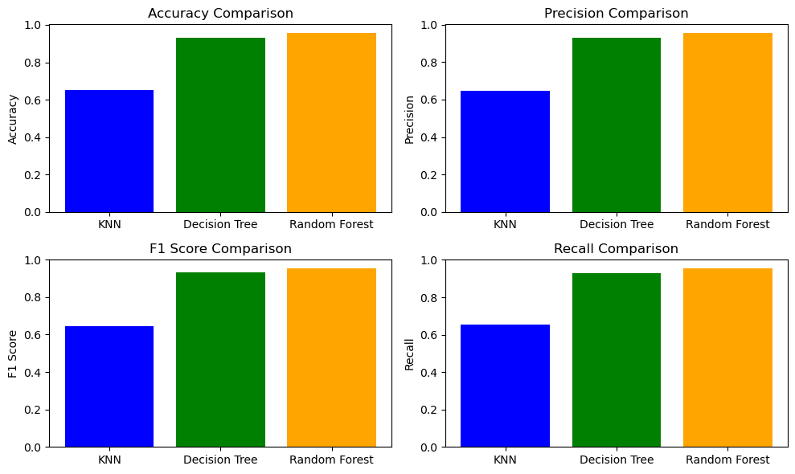

```
Best model based on accuracy: Random Forest
Best model based on precision: Random Forest
Best model based on F1 score: Random Forest
Best model based on recall: Random Forest
```

```python
import matplotlib.pyplot as plt

# Assuming 'models', 'acc_scores', 'prec_scores', 'f1_scores', 'recall_scores' are defined

# Find the best model based on accuracy
best_model_accuracy = models[acc_scores.index(max(acc_scores))]

# Find the best model based on precision
best_model_precision = models[prec_scores.index(max(prec_scores))]

# Find the best model based on F1 score
best_model_f1 = models[f1_scores.index(max(f1_scores))]

# Find the best model based on recall
best_model_recall = models[recall_scores.index(max(recall_scores))]

# Plot the results
plt.figure(figsize=(10, 6))

# Bar plot for accuracy
plt.subplot(2, 2, 1)
plt.bar(models, acc_scores, color=['blue', 'green', 'orange'])
plt.title('Accuracy Comparison')
plt.ylabel('Accuracy')

# Bar plot for precision
plt.subplot(2, 2, 2)
plt.bar(models, prec_scores, color=['blue', 'green', 'orange'])
plt.title('Precision Comparison')
plt.ylabel('Precision')

# Bar plot for F1 score
plt.subplot(2, 2, 3)
plt.bar(models, f1_scores, color=['blue', 'green', 'orange'])
plt.title('F1 Score Comparison')
plt.ylabel('F1 Score')

# Bar plot for recall
plt.subplot(2, 2, 4)
plt.bar(models, recall_scores, color=['blue', 'green', 'orange'])
plt.title('Recall Comparison')
plt.ylabel('Recall')

plt.tight_layout()
plt.show()

# Print the best models based on different metrics
print(f'Best model based on accuracy: {best_model_accuracy}')
print(f'Best model based on precision: {best_model_precision}')
print(f'Best model based on F1 score: {best_model_f1}')
print(f'Best model based on recall: {best_model_recall}')
```